# Analyse des prix des denrées sur les marchés Togolais (2026)

KAGNIRA Bihèbè

04 mai 2026

```r
knitr::opts_chunk$set(
  echo = TRUE,
  message = FALSE,
  warning = FALSE
)

library(tidyverse)
library(janitor)
library(scales)
library(readxl)
```

# 1. Contexte du projet

Ce rapport présente une analyse exploratoire des prix moyens des denrées alimentaires observés sur les marchés Togolais entre novembre 2025 et mars 2026, à partir des données collectées par la Direction de la Planification, des Statistiques Agricoles et Suivi‑Évaluation (DPSSE). Dans le contexte d’une inflation alimentaire globalement maîtrisée mais encore marquée par des pics de prix sur certains produits de base, la compréhension des niveaux et des variations de prix au niveau des marchés locaux devient un enjeu clé pour la sécurité alimentaire des ménages.

L’objectif principal de ce travail est de décrire les niveaux de prix par produit, région, préfecture et type de marché, d’identifier les produits et zones les plus exposés à des prix élevés ou volatils, et d’examiner les écarts susceptibles d’affecter le pouvoir d’achat et la disponibilité des denrées. Pour ce faire, une analyse exploratoire détaillée est combinée à une modélisation statistique simple, basée sur la régression linéaire appliquée au logarithme des prix, ainsi qu’à une première exploration de modèle mixte prenant en compte la structure hiérarchique des données (marchés et produits).

# 2. Description des données

```r
# Chargement des données:
 prix_marche2 <- read_excel("C:/Users/LENOVO/Desktop/HAINGA/donnees/donneescrees/prix_marché_Nov_Mars.xlsx")

# Vérification rapide de la structure
glimpse(prix_marche2)
```

```
## Rows: 20,948
## Columns: 13
## $ Pays               <chr> "Togo", "Togo", "Togo", "Togo", "Togo", "Togo", "To…
## $ Sources            <chr> "DPSSE", "DPSSE", "DPSSE", "DPSSE", "DPSSE", "DPSSE…
## $ Régions            <chr> "CENTRALE", "CENTRALE", "CENTRALE", "CENTRALE", "CE…
## $ Prefectures        <chr> "BLITTA", "BLITTA", "BLITTA", "BLITTA", "BLITTA", "…
## $ `Types de marchés` <chr> "Production", "Production", "Production", "Producti…
## $ Marches            <chr> "ASSOUKOKO", "ASSOUKOKO", "ASSOUKOKO", "ASSOUKOKO",…
## $ Produits           <chr> "ARACHIDE GROSSE GRAINE DECORTIQUE", "ARACHIDE PETI…
## $ Mois               <chr> "Février", "Février", "Février", "Février", "Févrie…
## $ Annee              <dbl> 2026, 2026, 2026, 2026, 2026, 2026, 2026, 2026, 202…
## $ Currency           <chr> "X0F", "X0F", "X0F", "X0F", "X0F", "X0F", "X0F", "X…
## $ Uninte             <chr> "KG", "KG", "KG", "KG", "KG", "KG", "KG", "KG", "KG…
## $ Type_Prix          <chr> "detail", "detail", "detail", "detail", "detail", "…
## $ prix_moy           <dbl> 862, 750, 928, 165, 1200, 1307, 240, 300, 1042, 148…
```

```r
summary(prix_marche2$prix_moy)
```

```
##    Min. 1st Qu.  Median    Mean 3rd Qu.    Max.
##    25.0   383.0   600.0   965.5  1200.0 13072.0
```

La base contient 20 948 enregistrements de prix moyens collectés sur les marchés du Togo en 2026, chaque ligne correspondant à un couple marché–produit–mois pour un prix de détail exprimé en FCFA par kilogramme. Les variables couvrent le pays, la région, la préfecture, le type de marché, le marché, le produit, le mois, l’année, la devise et le type de prix, ce qui permet une analyse détaillée des niveaux de prix dans l’espace et dans le temps.

La distribution est fortement asymétrique à droite, avec une médiane autour de 600 FCFA/kg et une moyenne plus élevée (~966 FCFA/kg), ce qui reflète la coexistence de produits de base peu chers et de produits à forte valeur ajoutée. Les valeurs très élevées doivent toutefois être examinées au cas par cas, pour distinguer les produits réellement chers (comme certains produits transformés ou de niche) d’éventuelles erreurs de saisie.

# 3. Nettoyage minimal et vérifications

```r
prix_marche <- prix_marche2 %>%
  clean_names() %>%
  mutate(
    mois = factor(
      mois,
      levels = c("Novembre", "Décembre", "Janvier", "Février", "Mars")
    ),
    regions = as.factor(regions),
    types_de_marches = as.factor(types_de_marches),
    produits = as.factor(produits)
  )

# Vérification des colonnes
colnames(prix_marche)
```

```
##  [1] "pays"             "sources"          "regions"          "prefectures"
##  [5] "types_de_marches" "marches"          "produits"         "mois"
##  [9] "annee"            "currency"         "uninte"           "type_prix"
## [13] "prix_moy"
```

```r
# Vérification des NA
prix_marche %>%
  summarise(across(everything(), ~sum(is.na(.))))
```

| pays | sources | regions | prefectures | types_de_marches | marches | produits | mois | annee | currency | uninte | type_prix | prix_moy |
| --- | --- | --- | --- | --- | --- | --- | --- | --- | --- | --- | --- | --- |
| 0 | 0 | 0 | 0 | 0 | 0 | 0 | 0 | 0 | 0 | 0 | 0 | 0 |

```r
# Détection de doublons
prix_marche %>%
  get_dupes(marches, produits, mois, annee)
```

| marches | produits | mois | annee | dupe_count | pays | sources | regions | prefectures | types_de_marches | currency | uninte | type_prix | prix_moy |
| --- | --- | --- | --- | --- | --- | --- | --- | --- | --- | --- | --- | --- | --- |
| ELAVAGNON | GOUSSI DECORTIQUE | Mars | 2026 | 4 | Togo | DPSSE | PLATEAUX | Est-Mono | Consommation | XOF | KG | detail | 1632 |
| ELAVAGNON | GOUSSI DECORTIQUE | Mars | 2026 | 4 | Togo | DPSSE | PLATEAUX | Est-Mono | Consommation | XOF | KG | detail | 1263 |
| ELAVAGNON | GOUSSI DECORTIQUE | Mars | 2026 | 4 | Togo | DPSSE | PLATEAUX | Est-Mono | Consommation | XOF | KG | detail | 2800 |
| ELAVAGNON | GOUSSI DECORTIQUE | Mars | 2026 | 4 | Togo | DPSSE | PLATEAUX | Est-Mono | Consommation | XOF | KG | detail | 1858 |
| ELAVAGNON | ARACHIDE PETITE GRAINE DECROTIQUE | Mars | 2026 | 3 | Togo | DPSSE | PLATEAUX | Est-Mono | Consommation | XOF | KG | detail | 810 |
| ELAVAGNON | ARACHIDE PETITE GRAINE DECROTIQUE | Mars | 2026 | 3 | Togo | DPSSE | PLATEAUX | Est-Mono | Consommation | XOF | KG | detail | 1700 |
| ELAVAGNON | ARACHIDE PETITE GRAINE DECROTIQUE | Mars | 2026 | 3 | Togo | DPSSE | PLATEAUX | Est-Mono | Consommation | XOF | KG | detail | 1089 |
| ELAVAGNON | MAIS BLANC | Mars | 2026 | 3 | Togo | DPSSE | PLATEAUX | Est-Mono | Consommation | XOF | KG | detail | 131 |
| ELAVAGNON | MAIS BLANC | Mars | 2026 | 3 | Togo | DPSSE | PLATEAUX | Est-Mono | Consommation | XOF | KG | detail | 275 |
| ELAVAGNON | MAIS BLANC | Mars | 2026 | 3 | Togo | DPSSE | PLATEAUX | Est-Mono | Consommation | XOF | KG | detail | 220 |

[output cut: 453 more lines]

```r
# Garder la première ligne des doublons
prix_marche <- prix_marche %>%
  group_by(marches, produits, mois, annee) %>%
  summarise(
    prix_moy = mean(prix_moy),
    regions = first(regions),
    types_de_marches = first(types_de_marches),
    prefectures = first(prefectures),
    .groups = "drop"
  )

# reverifier à nouveau
prix_marche %>%
  janitor::get_dupes(marches, produits, mois, annee)
```

| marches | produits | mois | annee | dupe_count | prix_moy | regions | types_de_marches | prefectures |
| --- | --- | --- | --- | --- | --- | --- | --- | --- |

```r
# Vérification des unités
table(prix_marche$uninte)
```

```
## < table of extent 0 >
```

```r
summary(prix_marche$prix_moy)
```

```
##    Min. 1st Qu.  Median    Mean 3rd Qu.    Max.
##    25.0   386.0   600.0   968.1  1200.0 13072.0
```

```r
# Valeurs suspectes
prix_marche %>% filter(prix_moy <= 0)
```

| marches | produits | mois | annee | prix_moy | regions | types_de_marches | prefectures |
| --- | --- | --- | --- | --- | --- | --- | --- |

```r
# Valeurs extrêmes
prix_marche %>%
  filter(prix_moy > 10000) %>%
  select(produits, regions, prix_moy) %>%
  arrange(desc(prix_moy))
```

| produits | regions | prix_moy |
| --- | --- | --- |
| FONIO | GRAND LOME | 13072 |

```r
# Quantiles détaillés
quantile(prix_marche$prix_moy, probs = c(0.01, 0.05, 0.5, 0.95, 0.99))
```

```
##      1%      5%     50%     95%     99%
##  143.55  197.25  600.00 3000.00 3975.00
```

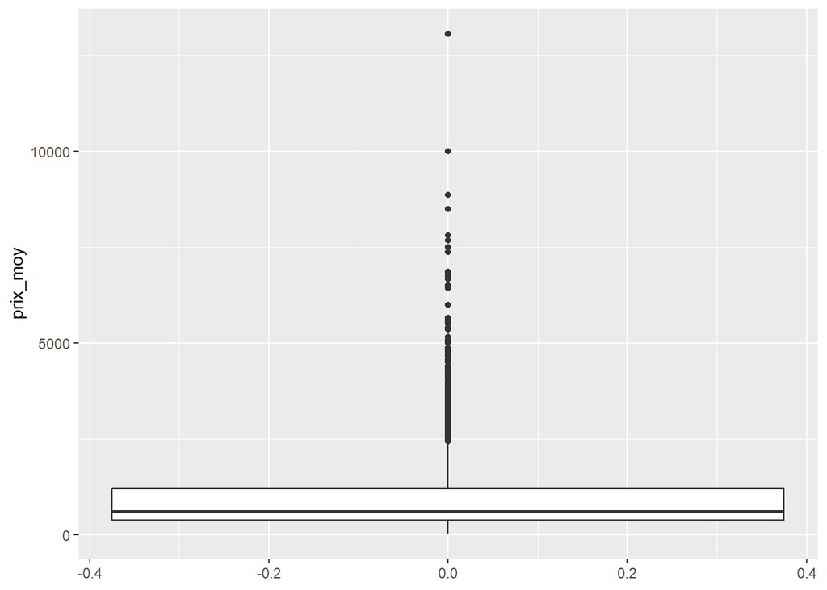

```r
# Distribution visuelle
ggplot(prix_marche, aes(y = prix_moy)) +
  geom_boxplot()
```

Les noms de variables ont été standardisés en minuscules avec des underscores, et plusieurs variables clés (mois, régions, types de marchés, produits) ont été converties en facteurs pour faciliter les agrégations et les visualisations. Aucune valeur manquante n’est détectée dans les colonnes de localisation et de période, et les contrôles montrent l’absence de prix nuls ou négatifs, ce qui renforce la fiabilité de l’analyse descriptive. Les quelques valeurs extrêmes identifiées concernent notamment le fonio dans le Grand Lomé, dont le niveau de prix très élevé est cohérent avec un produit spécifique à forte valeur et non avec une erreur évidente.

Les doublons identifiés pour certaines combinaisons marché–produit–mois–année correspondent à plusieurs observations de prix pour une même situation. Afin de conserver toute l’information disponible tout en évitant une surreprésentation de ces cas, les valeurs ont été agrégées en calculant le prix moyen pour chaque combinaison. Ce choix revient à considérer que ces observations reflètent des relevés multiples d’un même phénomène, et permet d’obtenir une estimation plus robuste du niveau de prix.

# 4. Vue d’ensemble des prix

## 4.1 Distribution générale des prix

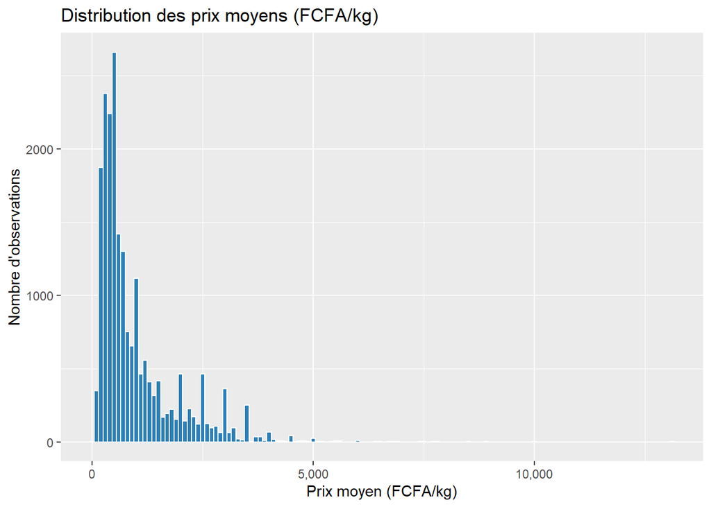

```r
ggplot(prix_marche, aes(x = prix_moy)) +
  geom_histogram(binwidth = 100, fill = "#2c7fb8", color = "white") +
  scale_x_continuous(labels = comma) +
  labs(
    title = "Distribution des prix moyens (FCFA/kg)",
    x = "Prix moyen (FCFA/kg)",
    y = "Nombre d'observations"
  )
```

La distribution des prix moyens est très étalée : la majorité des observations se situe entre environ 200 et 1 200 FCFA/kg, mais une fraction non négligeable dépasse 3 000 FCFA/kg. La moyenne est nettement supérieure à la médiane, ce qui confirme une asymétrie vers le haut liée à quelques produits très chers qui tirent la distribution.

## 4.2 Produits les plus chers et les moins chers

```r
top_produits <- prix_marche %>%
  group_by(produits) %>%
  summarise(
    prix_moy_national = mean(prix_moy, na.rm = TRUE),
    n_obs = n()
  ) %>%
  ungroup() %>%
  arrange(desc(prix_moy_national))

# Top 10 des produits les plus chers
head(top_produits, 10)
```

| produits | prix_moy_national | n_obs |
| --- | --- | --- |
| PINTADE | 3469.055 | 164 |
| VIANDE DE CHEVRE | 3162.272 | 202 |
| VIANDE DE MOUTON | 3057.385 | 195 |
| MIEL | 2847.442 | 147 |
| Plateau d'œufs de pintade | 2745.575 | 134 |
| VIANDE DE BOEUF | 2685.899 | 247 |
| PETIT POISSON FUME | 2449.323 | 198 |
| PETIT POISSON SECHE | 2351.733 | 191 |
| POULET BICYCLETE | 2307.966 | 146 |
| POULET DE CHAIR | 2278.030 | 165 |

```r
# Top 10 des produits les moins chers
tail(top_produits, 10)
```

| produits | prix_moy_national | n_obs |
| --- | --- | --- |
| ANANAS | 325.9938 | 161 |
| MANIOC FRAIS | 323.4851 | 202 |
| SOJA | 287.2608 | 269 |
| NOIX DE COCO | 283.6424 | 165 |
| ORANGE | 272.5380 | 158 |
| SORGHO BLANC | 258.1354 | 229 |
| SORGHO ROUGE | 254.9560 | 269 |
| RIZ PADDY | 235.6616 | 232 |
| MAIS JAUNE | 184.5996 | 256 |
| MAIS BLANC | 178.5492 | 278 |

Les produits les plus chers sont principalement des protéines animales (pintade, viandes de chèvre, mouton et bœuf) et des produits à forte valeur ajoutée comme le miel, les œufs de pintade et certains poissons fumés ou séchés. À l’inverse, les produits les moins chers sont surtout des produits de base (maïs blanc et jaune, sorgho, riz paddy, manioc frais, soja, ananas et agrumes) qui constituent l’essentiel du panier alimentaire courant des ménages.

# 4.3 Variabilité des prix par produit

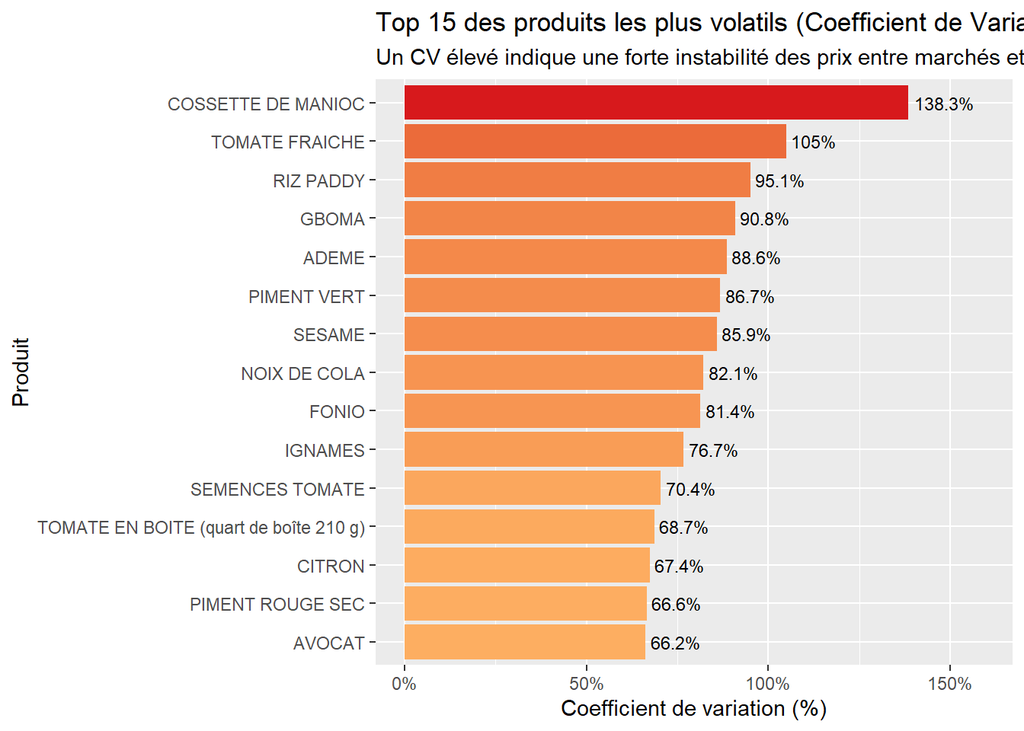

```r
variabilite_produits <- prix_marche %>%
  group_by(produits) %>%
  summarise(
    moyenne = mean(prix_moy),
    sd      = sd(prix_moy),
    cv      = sd(prix_moy) / moyenne
  ) %>%
  arrange(desc(cv))

#  Graphique Top 15 produits les plus volatils
variabilite_produits %>%
  slice_max(cv, n = 15) %>%
  ggplot(aes(
    x    = reorder(produits, cv),
    y    = cv,
    fill = cv
  )) +
  geom_col() +
  geom_text(
    aes(label = paste0(round(cv * 100, 1), "%")),
    hjust = -0.1, size = 3
  ) +
  coord_flip() +
  scale_fill_gradient(low = "#fdae61", high = "#d7191c") +
  scale_y_continuous(
    labels = percent_format(),
    limits = c(0, max(variabilite_produits$cv) * 1.15)
  ) +
  theme(legend.position = "none") +
  labs(
    title    = "Top 15 des produits les plus volatils (Coefficient de Variation)",
    subtitle = "Un CV élevé indique une forte instabilité des prix entre marchés et mois",
    x        = "Produit",
    y        = "Coefficient de variation (%)"
  )
```

```r
#  Tableau synthétique volatilité
# On crée d'abord un objet intermédiaire AVANT le mutate
top15_volatils <- variabilite_produits %>%
  slice_max(cv, n = 15)          # <- slice_max ICI, sur l'objet original

top15_volatils %>%
  mutate(
    cv_pct    = paste0(round(cv * 100, 1), "%"),
    moyenne   = round(moyenne, 0),
    sd        = round(sd, 0),
    Stabilité = case_when(
      cv < 0.20 ~ "Stable",
      cv < 0.40 ~ "Modéré",
      TRUE      ~ "Volatile"
    )
  ) %>%
  select(
    Produit      = produits,
    `Prix moyen` = moyenne,
    `Écart-type` = sd,
    CV           = cv_pct,
    Stabilité
  ) %>%
  knitr::kable(caption = "Produits les plus volatils — novembre 2025 à mars 2026")
```

Produits les plus volatils — novembre 2025 à mars 2026

| Produit | Prix moyen | Écart-type | CV | Stabilité |
| --- | --- | --- | --- | --- |
| COSSETTE DE MANIOC | 395 | 546 | 138.3% | Volatile |
| TOMATE FRAICHE | 592 | 621 | 105% | Volatile |
| RIZ PADDY | 236 | 224 | 95.1% | Volatile |
| GBOMA | 533 | 484 | 90.8% | Volatile |
| ADEME | 596 | 528 | 88.6% | Volatile |
| PIMENT VERT | 750 | 650 | 86.7% | Volatile |
| SESAME | 668 | 574 | 85.9% | Volatile |
| NOIX DE COLA | 1023 | 840 | 82.1% | Volatile |
| FONIO | 1274 | 1036 | 81.4% | Volatile |
| IGNAMES | 597 | 458 | 76.7% | Volatile |
| SEMENCES TOMATE | 562 | 396 | 70.4% | Volatile |
| TOMATE EN BOITE (quart de boîte 210 g) | 418 | 287 | 68.7% | Volatile |
| CITRON | 531 | 358 | 67.4% | Volatile |
| PIMENT ROUGE SEC | 1443 | 961 | 66.6% | Volatile |
| AVOCAT | 612 | 405 | 66.2% | Volatile |

# 5. Analyse géographique

## 5.1 Prix moyens par région

```r
mediane_nationale <- median(prix_marche$prix_moy, na.rm = TRUE)
```

```r
prix_region <- prix_marche %>%
  group_by(regions) %>%
  summarise(
    prix_moy_region = mean(prix_moy, na.rm = TRUE),
    n_obs = n()
  ) %>%
  arrange(desc(prix_moy_region))
```

```r
ecart_region <- prix_marche %>%
  group_by(regions) %>%
  summarise(
    prix_median_region = median(prix_moy, na.rm = TRUE)
  ) %>%
  mutate(
    ecart_pct = (prix_median_region - mediane_nationale) /
                mediane_nationale * 100
  ) %>%
  arrange(desc(ecart_pct))
```

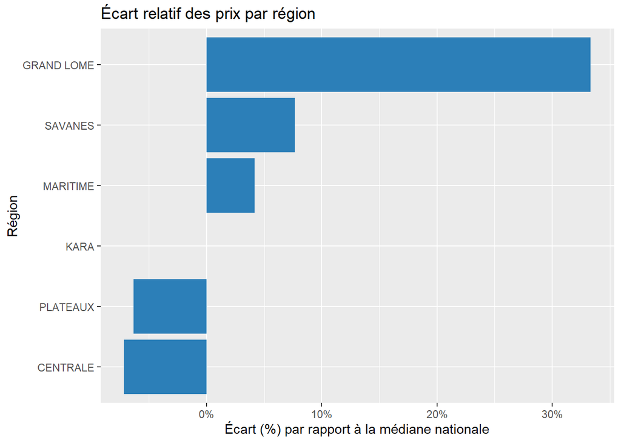

```r
ggplot(ecart_region, aes(
  x = reorder(regions, ecart_pct),
  y = ecart_pct
)) +
  geom_col(fill = "#2c7fb8") +
  coord_flip() +
  scale_y_continuous(labels = function(x) paste0(round(x, 1), "%")) +
  labs(
    title = "Écart relatif des prix par région",
    x = "Région",
    y = "Écart (%) par rapport à la médiane nationale"
  )
```

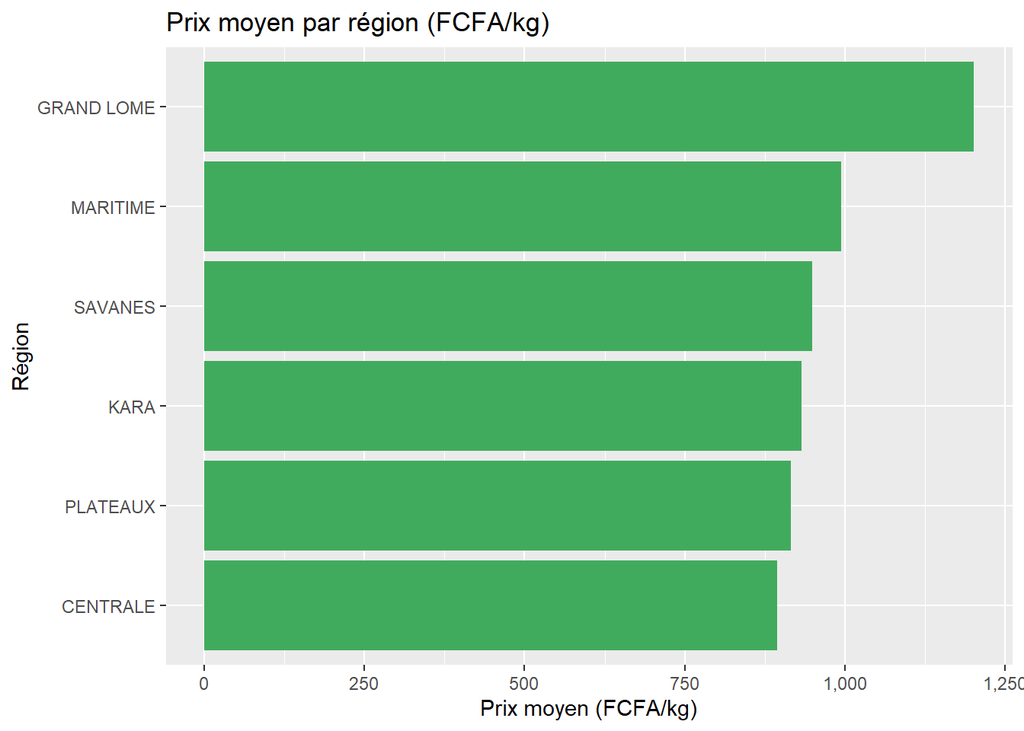

```r
ggplot(prix_region, aes(
  x = reorder(regions, prix_moy_region),
  y = prix_moy_region
)) +
  geom_col(fill = "#41ab5d") +
  coord_flip() +
  scale_y_continuous(labels = scales::comma) +
  labs(
    title = "Prix moyen par région (FCFA/kg)",
    x = "Région",
    y = "Prix moyen (FCFA/kg)"
  )
```

## 5.2 Prix d’un produit clé par région

```r
# Le maïs étant un aliment de base de tous les Togolais
produit_cible <- "MAIS BLANC"

prix_maïs_region <- prix_marche %>%
  filter(str_detect(toupper(produits), produit_cible)) %>%
  group_by(regions) %>%
  summarise(
    prix_moy_region = median(prix_moy),
    n_obs = n()
  ) %>%
  arrange(desc(prix_moy_region))

prix_maïs_region
```

| regions | prix_moy_region | n_obs |
| --- | --- | --- |
| GRAND LOME | 192 | 33 |
| MARITIME | 177 | 29 |
| KARA | 173 | 51 |
| CENTRALE | 169 | 45 |
| PLATEAUX | 157 | 82 |
| SAVANES | 154 | 38 |

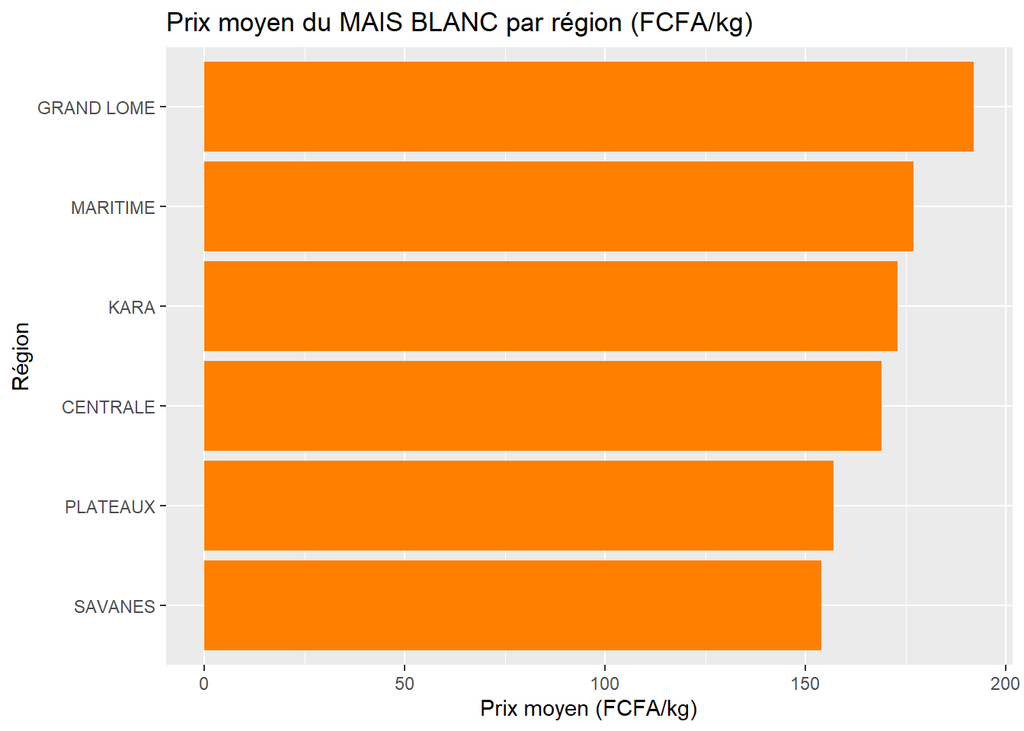

```r
ggplot(prix_maïs_region, aes(x = reorder(regions, prix_moy_region), y = prix_moy_region)) +
  geom_col(fill = "#ff7f00") +
  coord_flip() +
  scale_y_continuous(labels = comma) +
  labs(
    title = paste("Prix moyen du", produit_cible, "par région (FCFA/kg)"),
    x = "Région",
    y = "Prix moyen (FCFA/kg)"
  )
```

```r
prix_marche %>%
  filter(produits == "MAIS BLANC") %>%
  group_by(types_de_marches) %>%
  summarise(prix = mean(prix_moy))
```

| types_de_marches | prix |
| --- | --- |
| Consommation | 192.9312 |
| Production | 170.0565 |
| Regroupement | 173.6690 |

Pour le maïs blanc, produit de base, les prix les plus élevés se trouvent également dans le Grand Lomé (environ 190–200 FCFA/kg), alors que les régions plus rurales comme les Plateaux, la Centrale, la Kara et les Savanes affichent des niveaux légèrement plus bas. Cet écart, combiné au fait que les marchés de consommation pratiquent en moyenne des prix plus élevés que les marchés de production, suggère un effet conjoint des coûts de transport, de la demande urbaine et des marges commerciales le long de la chaîne de commercialisation.

## 5.3 Analyse par préfecture

```r
# Prix moyen par préfecture
prix_prefecture <- prix_marche %>%
  group_by(regions, prefectures) %>%
  summarise(
    prix_moyen   = mean(prix_moy, na.rm = TRUE),
    prix_median  = median(prix_moy, na.rm = TRUE),
    n_obs        = n(),
    .groups      = "drop"
  ) %>%
  arrange(desc(prix_moyen))

# Top 10 préfectures les plus chères
prix_prefecture %>%
  slice_max(prix_moyen, n = 10) %>%
  knitr::kable(
    col.names = c("Région", "Préfecture", "Prix moyen", "Prix médian", "Nb obs"),
    caption   = "Top 10 des préfectures avec les prix moyens les plus élevés",
    digits    = 0
  )
```

Top 10 des préfectures avec les prix moyens les plus élevés

| Région | Préfecture | Prix moyen | Prix médian | Nb obs |
| --- | --- | --- | --- | --- |
| PLATEAUX | Kloto | 1793 | 750 | 52 |
| GRAND LOME | Agoenyive | 1382 | 1000 | 398 |
| MARITIME | Avé | 1311 | 900 | 124 |
| PLATEAUX | Est-Mono | 1269 | 958 | 201 |
| PLATEAUX | Moyen-Mono | 1265 | 900 | 41 |
| SAVANES | Oti | 1254 | 900 | 130 |
| GRAND LOME | Golfe | 1251 | 800 | 431 |
| KARA | Assoli | 1239 | 866 | 68 |
| GRAND LOME | GOLFE | 1167 | 773 | 1167 |
| SAVANES | Tandjoaré | 1154 | 875 | 107 |

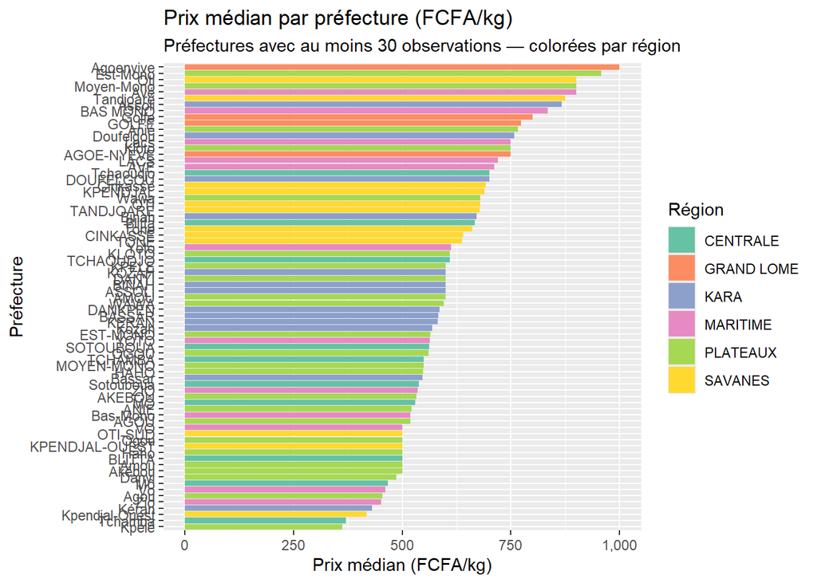

```r
# Graphique : prix médian par préfecture coloré par région
ggplot(
  prix_prefecture %>% filter(n_obs >= 30),   # préfectures avec suffisamment d'obs
  aes(
    x    = reorder(prefectures, prix_median),
    y    = prix_median,
    fill = regions
  )
) +
  geom_col() +
  coord_flip() +
  scale_y_continuous(labels = comma) +
  scale_fill_brewer(palette = "Set2") +
  labs(
    title    = "Prix médian par préfecture (FCFA/kg)",
    subtitle = "Préfectures avec au moins 30 observations — colorées par région",
    x        = "Préfecture",
    y        = "Prix médian (FCFA/kg)",
    fill     = "Région"
  )
```

[figure not shown]

```r
# Carte thermique : préfecture × produit (maïs, riz, ignames)
produits_focus <- c("MAIS BLANC", "RIZ DE GRANDE CONSOMMATION", "IGNAMES")

prix_marche %>%
  filter(produits %in% produits_focus) %>%
  group_by(prefectures, produits) %>%
  summarise(prix_med = median(prix_moy), .groups = "drop") %>%
  ggplot(aes(x = produits, y = reorder(prefectures, prix_med), fill = prix_med)) +
  geom_tile(color = "white") +
  scale_fill_gradient(
    low    = "#ffffb2",
    high   = "#d7191c",
    labels = comma,
    name   = "Prix médian\n(FCFA/kg)"
  ) +
  geom_text(aes(label = round(prix_med, 0)), size = 2.5) +
  labs(
    title    = "Carte thermique des prix médians par préfecture et produit",
    subtitle = "Produits de base sélectionnés",
    x        = "Produit",
    y        = "Préfecture"
  ) +
  theme(axis.text.y = element_text(size = 7))
```

L’analyse au niveau des préfectures révèle des disparités plus fines que celles observées à l’échelle régionale. Certaines préfectures affichent des prix médians nettement supérieurs à la moyenne de leur région, ce qui peut indiquer des problèmes d’accessibilité géographique, une offre locale insuffisante ou des coûts de transport élevés. La carte thermique permet d’identifier rapidement les combinaisons préfecture–produit les plus critiques, utiles pour cibler des interventions de sécurité alimentaire.

# 6. Effet du type de marché

## 6.1 Boxplots par type de marché

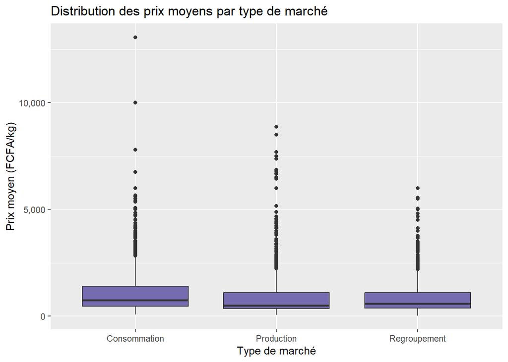

```r
ggplot(prix_marche, aes(x = types_de_marches, y = prix_moy)) +
  geom_boxplot(fill = "#756bb1") +
  scale_y_continuous(labels = comma) +
  labs(
    title = "Distribution des prix moyens par type de marché",
    x = "Type de marché",
    y = "Prix moyen (FCFA/kg)"
  )
```

Les boxplots montrent que les marchés de consommation pratiquent, en moyenne, des prix plus élevés et plus dispersés que les marchés de production. Les marchés de regroupement se situent dans une position intermédiaire, ce qui est cohérent avec leur rôle de zones de transit et de concentration avant redistribution vers d’autres marchés. Cette hiérarchie est retrouvée pour plusieurs produits, ce qui renforce l’idée de marges commerciales plus fortes au niveau des marchés de détail.

## 6.2 Focus sur quelques produits de base

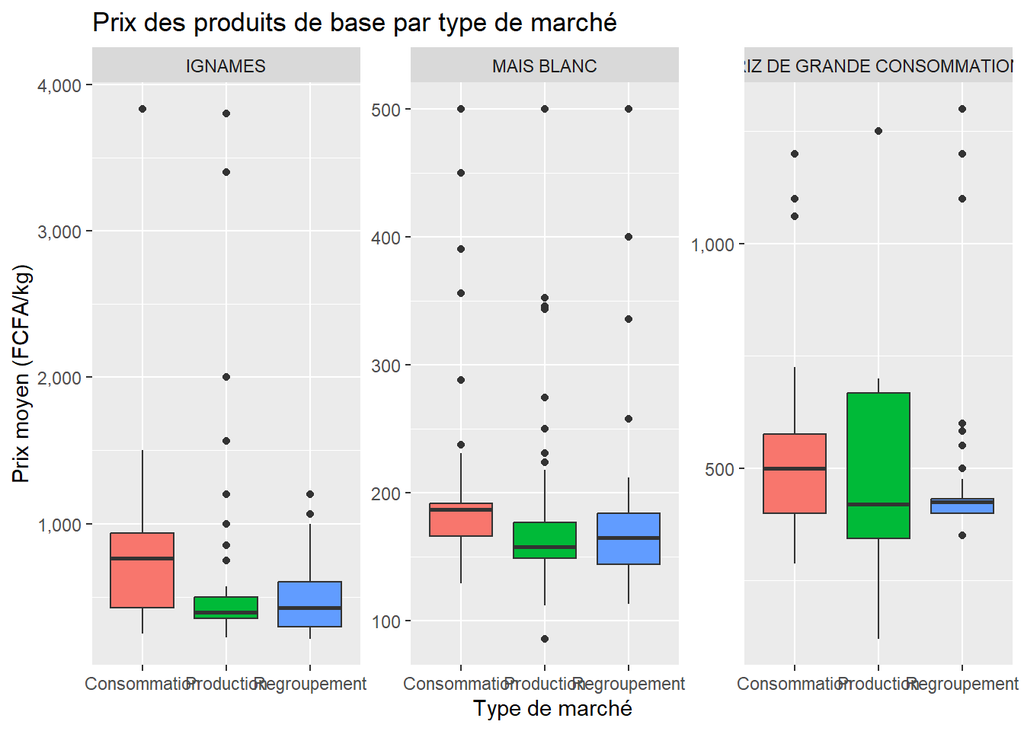

```r
produits_cibles <- c("MAIS BLANC", "RIZ DE GRANDE CONSOMMATION", "IGNAMES")

prix_base <- prix_marche %>%
  filter(str_detect(toupper(produits), str_c(produits_cibles, collapse = "|")))

ggplot(prix_base, aes(x = types_de_marches, y = prix_moy, fill = types_de_marches)) +
  geom_boxplot() +
  facet_wrap(~ produits, scales = "free_y") +
  scale_y_continuous(labels = comma) +
  theme(legend.position = "none") +
  labs(
    title = "Prix des produits de base par type de marché",
    x = "Type de marché",
    y = "Prix moyen (FCFA/kg)"
  )
```

Pour les produits de base comme le maïs blanc, le riz de grande consommation et les ignames, les prix sont systématiquement plus élevés sur les marchés de consommation que sur les marchés de production. Cela confirme l’existence de marges entre producteurs et détaillants et met en évidence des différentiels de prix susceptibles de peser davantage sur le pouvoir d’achat des ménages urbains, particulièrement en période de hausse générale des prix.

# 7. Variation temporelle

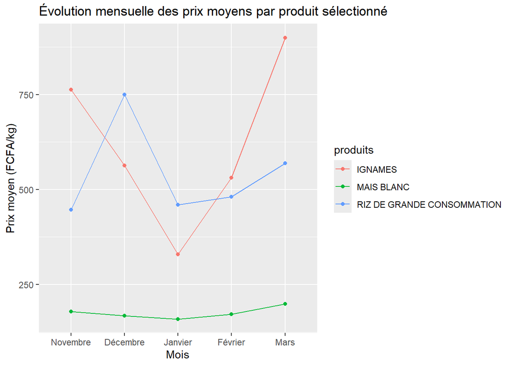

```r
prix_mensuel <- prix_marche %>%
  group_by(mois, produits) %>%
  summarise(
    prix_moy_mois = mean(prix_moy, na.rm = TRUE),
    n_obs = n()
  ) %>%
  ungroup()

prix_mensuel %>%
  filter(produits %in% unique(prix_base$produits)) %>%
  ggplot(aes(x = mois, y = prix_moy_mois, group = produits, color = produits)) +
  geom_line() +
  geom_point() +
  scale_y_continuous(labels = comma) +
  labs(
    title = "Évolution mensuelle des prix moyens par produit sélectionné",
    x = "Mois",
    y = "Prix moyen (FCFA/kg)"
  )
```

Sur la période analysée (novembre à mars), on observe des variations mensuelles de prix qui restent modérées pour certains produits et plus marquées pour d’autres, en fonction des saisons de récolte et des conditions d’approvisionnement. Pour les produits de base, les hausses entre certains mois peuvent signaler des tensions ponctuelles sur l’offre ou des effets saisonniers spécifiques, ce qui justifie un suivi régulier pour anticiper d’éventuelles difficultés d’accès aux denrées.

# 8. Piste de modèle simple

```r
modele_prix <- lm(
  log(prix_moy) ~ produits + regions + types_de_marches + mois,
  data = prix_marche
)
```

```r
modele_sans_produit <- lm(
  log(prix_moy) ~ regions + types_de_marches + mois,
  data = prix_marche
)
```

```r
summary(modele_prix)
```

```
##
## Call:
## lm(formula = log(prix_moy) ~ produits + regions + types_de_marches +
##     mois, data = prix_marche)
##
## Residuals:
##     Min      1Q  Median      3Q     Max
## -3.3214 -0.1728  0.0043  0.1681  3.2307
##
## Coefficients:
##                                                            Estimate Std. Error
## (Intercept)                                                6.297099   0.029328
## produitsANANAS                                            -0.572090   0.039187
## produitsARACHIDE GROSSE GRAINE DECORTIQUE                  0.447134   0.034877
## produitsARACHIDE PETITE GRAINE DECROTIQUE                  0.407274   0.035137
## produitsAUBERGINE                                         -0.096883   0.037667
## produitsAVOCAT                                             0.016812   0.038433
## produitsBANANE DOUCE                                      -0.077377   0.040114
## produitsBANANE PLANTAIN                                    0.330211   0.040348
## produitsBETTERAVES                                         0.105607   0.038798
## produitsBEURRE DE KARITE (KG)                              0.851310   0.039813
## produitsBlé                                                0.077393   0.040756
## produitsCAROTTE                                            0.290026   0.038433
## produitsCHOUX                                             -0.016398   0.038204
## produitsCITRON                                            -0.084633   0.038735
## produitsCONCOMBRE                                         -0.016174   0.038735
## produitsCOSSETTE DE MANIOC                                -0.495547   0.035385
## produitsCouscous (Bnjourne 1Kg)                            0.612837   0.036959
## produitsCouscous (Khoulala 1Kg)                            0.660992   0.038990
## produitsFONIO                                              0.806077   0.038932
## produitsFROMAGE                                            0.958852   0.041565
## produitsGARI                                              -0.354479   0.034580
## produitsGBOMA                                             -0.090917   0.036955
## produitsGINGEMBRE                                          1.047670   0.037873
## produitsGOMBO FRAIS                                        0.092579   0.037466
## produitsGOMBO SEC                                          1.009041   0.035514
## produitsGOUSSI DECORTIQUE                                  0.976834   0.035751
## produitsGOUSSI NON DECORTIQUE                              0.238884   0.035617
## produitsGRAIN DE NERE                                      0.720106   0.040513
## produitsHARICOT BLANC                                     -0.089908   0.034553
```

[output cut: 207 more lines]

```
## regionsMARITIME                                             4.318 1.58e-05 ***
## regionsPLATEAUX                                            -1.106 0.268759
## regionsSAVANES                                              1.778 0.075420 .
## types_de_marchesProduction                                -31.273  < 2e-16 ***
## types_de_marchesRegroupement                              -20.383  < 2e-16 ***
## moisDécembre                                               -4.865 1.15e-06 ***
## moisJanvier                                                -5.291 1.23e-07 ***
## moisFévrier                                                 4.891 1.01e-06 ***
## moisMars                                                    8.679  < 2e-16 ***
## ---
## Signif. codes:  0 '***' 0.001 '**' 0.01 '*' 0.05 '.' 0.1 ' ' 1
##
## Residual standard error: 0.3666 on 20589 degrees of freedom
## Multiple R-squared:  0.8009, Adjusted R-squared:  0.7998
## F-statistic: 684.7 on 121 and 20589 DF,  p-value: < 2.2e-16
```

```r
summary(modele_sans_produit)
```

```
##
## Call:
## lm(formula = log(prix_moy) ~ regions + types_de_marches + mois,
##     data = prix_marche)
##
## Residuals:
##     Min      1Q  Median      3Q     Max
## -3.2887 -0.5783 -0.1147  0.5720  2.6853
##
## Coefficients:
##                               Estimate Std. Error t value Pr(>|t|)
## (Intercept)                   6.547748   0.027743 236.012  < 2e-16 ***
## regionsGRAND LOME             0.166905   0.022641   7.372 1.75e-13 ***
## regionsKARA                   0.021711   0.019962   1.088  0.27676
## regionsMARITIME               0.038002   0.023682   1.605  0.10857
## regionsPLATEAUX               0.007389   0.018147   0.407  0.68389
## regionsSAVANES                0.026703   0.020966   1.274  0.20282
## types_de_marchesProduction   -0.218435   0.014204 -15.379  < 2e-16 ***
## types_de_marchesRegroupement -0.156497   0.014936 -10.478  < 2e-16 ***
## moisDécembre                 -0.169222   0.034760  -4.868 1.13e-06 ***
## moisJanvier                  -0.004860   0.026489  -0.183  0.85442
## moisFévrier                   0.119390   0.023784   5.020 5.22e-07 ***
## moisMars                      0.078298   0.025875   3.026  0.00248 **
## ---
## Signif. codes:  0 '***' 0.001 '**' 0.01 '*' 0.05 '.' 0.1 ' ' 1
##
## Residual standard error: 0.806 on 20699 degrees of freedom
## Multiple R-squared:  0.03256,    Adjusted R-squared:  0.03205
## F-statistic: 63.34 on 11 and 20699 DF,  p-value: < 2.2e-16
```

## 8.1 Prédictions du modèle

```r
# Prédictions sur l'échantillon utilisé pour estimer le modèle
pred_log <- predict(modele_prix)          # prédiction de log(prix_moy)
pred_prix <- exp(pred_log)                # prédiction du prix moyen (FCFA/kg)

#
prix_marche <- prix_marche %>%
  mutate(
    pred_log_prix = pred_log,
    pred_prix = pred_prix
  )

# comparaison du prix observé et le prix prédit pour quelques lignes
prix_marche %>%
  select(produits, regions, types_de_marches, mois, prix_moy, pred_prix) %>%
  slice_head(n = 10)
```

| produits | regions | types_de_marches | mois | prix_moy | pred_prix |
| --- | --- | --- | --- | --- | --- |
| ADEME | PLATEAUX | Production | Février | 481 | 463.2484 |
| ANANAS | PLATEAUX | Production | Février | 300 | 261.4317 |
| ARACHIDE GROSSE GRAINE DECORTIQUE | PLATEAUX | Production | Février | 742 | 724.4392 |
| ARACHIDE PETITE GRAINE DECROTIQUE | PLATEAUX | Production | Février | 600 | 696.1308 |
| AUBERGINE | PLATEAUX | Production | Février | 388 | 420.4729 |
| AVOCAT | PLATEAUX | Production | Février | 500 | 471.1024 |
| BANANE DOUCE | PLATEAUX | Production | Février | 450 | 428.7554 |
| BANANE PLANTAIN | PLATEAUX | Production | Février | 675 | 644.4997 |
| BETTERAVES | PLATEAUX | Production | Février | 492 | 514.8471 |
| BEURRE DE KARITE (KG) | PLATEAUX | Production | Février | 1331 | 1085.2584 |

```r
# Prédictions pour le maïs blanc
newdata <- tibble(
  produits = factor(c("MAIS BLANC", "MAIS BLANC", "MAIS BLANC"),
                    levels = levels(prix_marche$produits)),
  regions = factor(c("GRAND LOME", "PLATEAUX", "SAVANES"),
                   levels = levels(prix_marche$regions)),
  types_de_marches = factor(c("Consommation", "Production", "Consommation"),
                            levels = levels(prix_marche$types_de_marches)),
  mois = factor(c("Janvier", "Janvier", "Janvier"),
                levels = levels(prix_marche$mois))
)

newdata <- newdata %>%
  mutate(
    pred_log = predict(modele_prix, newdata = newdata),
    pred_prix = exp(pred_log)
  )

newdata
```

| produits | regions | types_de_marches | mois | pred_log | pred_prix |
| --- | --- | --- | --- | --- | --- |
| MAIS BLANC | GRAND LOME | Consommation | Janvier | 5.273191 | 195.0374 |
| MAIS BLANC | PLATEAUX | Production | Janvier | 4.937969 | 139.4867 |
| MAIS BLANC | SAVANES | Consommation | Janvier | 5.167409 | 175.4596 |

```r
library(Metrics)

rmse_val <- rmse(prix_marche$prix_moy, prix_marche$pred_prix)
mape_val <- mape(prix_marche$prix_moy, prix_marche$pred_prix)

tibble(
  indicateur = c("RMSE (FCFA/kg)", "MAPE"),
  valeur = c(rmse_val, mape_val)
)
```

| indicateur | valeur |
| --- | --- |
| RMSE (FCFA/kg) | 465.8993843 |
| MAPE | 0.2748674 |

Le modèle linéaire appliqué au logarithme des prix met en évidence des associations fortes entre le niveau de prix et le type de produit, ce qui est attendu compte tenu de la diversité des denrées (produits de base, céréales, tubercules, huiles, produits animaux, etc.). À produit donné, la région du Grand Lomé présente un niveau de prix significativement plus élevé que la région de référence, tandis que les marchés de production et de regroupement affichent des niveaux de prix significativement plus faibles que les marchés de consommation, ce qui traduit des marges commerciales plus importantes au stade du détail. Avec un R² ajusté d’environ 0,80, le modèle explique une part importante de la variabilité du logarithme des prix, mais les coefficients doivent être interprétés comme des associations descriptives et non comme des effets causaux. Les erreurs de prédiction restent modérées, avec un RMSE d’environ 470 FCFA/kg et un MAPE proche de 28%, ce qui rend le modèle utile pour résumer la structure des prix, mais insuffisant pour des prévisions opérationnelles fines.

Afin de mieux comprendre le rôle des facteurs structurels indépendamment des différences entre produits, un second modèle a été estimé sans inclure la variable “produits”. Ce modèle permet d’évaluer les écarts de prix moyens entre régions et types de marchés, mais doit être interprété avec prudence, car il peut refléter en partie des effets de composition liés à la distribution des produits selon les zones.

À titre d’exemple, pour le maïs blanc en janvier, le modèle prédit un prix moyen d’environ 200 FCFA/kg sur un marché de consommation du Grand Lomé, contre des niveaux légèrement plus bas dans les régions de l’intérieur et sur les marchés de production, ce qui illustre concrètement l’effet combiné de la localisation et du type de marché.

## 8.2 Validation du modèle

```r
library(caret)
library(Metrics)

# 1. Partition unique 70/30

set.seed(123)
index <- sample(1:nrow(prix_marche), 0.7 * nrow(prix_marche))
train <- prix_marche[index, ]
test  <- prix_marche[-index, ]

modele_train <- lm(log(prix_moy) ~ produits + regions + types_de_marches + mois,
                   data = train)
pred_test <- exp(predict(modele_train, newdata = test))

rmse_holdout <- rmse(test$prix_moy, pred_test)
mape_holdout <- mape(test$prix_moy, pred_test)

cat("── Partition 70/30 ──\n")
```

```
## ── Partition 70/30 ──
```

```r
cat("RMSE :", round(rmse_holdout, 1), "FCFA/kg\n")
```

```
## RMSE : 462.4 FCFA/kg
```

```r
cat("MAPE :", round(mape_holdout * 100, 1), "%\n")
```

```
## MAPE : 28.8 %
```

```r
# 2. Validation croisée 5-fold
set.seed(123)
ctrl <- trainControl(method = "cv", number = 5, verboseIter = FALSE)

modele_cv <- train(
  log(prix_moy) ~ produits + regions + types_de_marches + mois,
  data    = prix_marche,
  method  = "lm",
  trControl = ctrl
)

cv_results <- modele_cv$results

# Conversion RMSE du log vers FCFA/kg (approximation via exponentielle)
rmse_log  <- cv_results$RMSE
rmse_fcfa <- exp(mean(log(prix_marche$prix_moy))) * (exp(rmse_log) - 1)

cat("\n── Validation croisée 5-fold ──\n")
```

```
##
## ── Validation croisée 5-fold ──
```

```r
cat("RMSE (log) :", round(rmse_log, 4), "\n")
```

```
## RMSE (log) : 0.3678
```

```r
cat("R²         :", round(cv_results$Rsquared, 4), "\n")
```

```
## R²         : 0.7985
```

```r
cat("MAE (log)  :", round(cv_results$MAE, 4), "\n")
```

```
## MAE (log)  : 0.2554
```

```r
# 3. Tableau comparatif des deux approches
tibble(
  Méthode      = c("Partition 70/30", "Validation croisée 5-fold"),
  `RMSE (FCFA/kg)` = c(round(rmse_holdout, 1), round(rmse_fcfa, 1)),
  `MAPE (%)`   = c(round(mape_holdout * 100, 1), NA_real_),
  `R² (log)`   = c(
    round(summary(modele_train)$r.squared, 4),
    round(cv_results$Rsquared, 4)
  )
) %>%
  knitr::kable(caption = "Comparaison des méthodes de validation")
```

Comparaison des méthodes de validation

| Méthode | RMSE (FCFA/kg) | MAPE (%) | R² (log) |
| --- | --- | --- | --- |
| Partition 70/30 | 462.4 | 28.8 | 0.8080 |
| Validation croisée 5-fold | 304.8 | NA | 0.7985 |

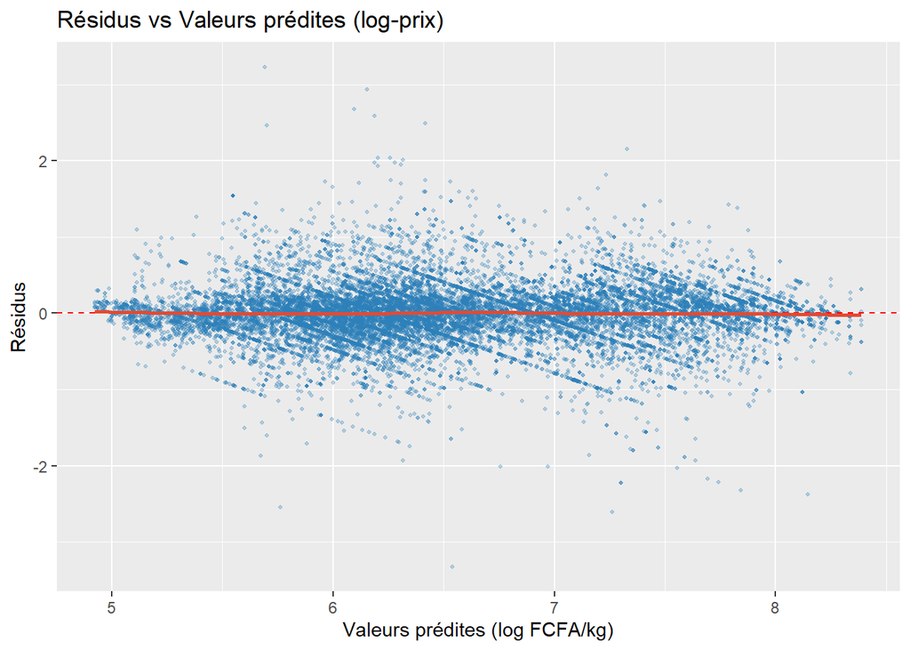

```r
# 4. Graphique résidus vs valeurs prédites
prix_marche <- prix_marche %>%
  mutate(
    residu    = log(prix_moy) - predict(modele_prix),
    pred_log2 = predict(modele_prix)
  )

ggplot(prix_marche, aes(x = pred_log2, y = residu)) +
  geom_point(alpha = 0.3, color = "#2c7fb8", size = 0.8) +
  geom_hline(yintercept = 0, color = "red", linetype = "dashed") +
  geom_smooth(method = "loess", se = FALSE, color = "#e34a33") +
  labs(
    title = "Résidus vs Valeurs prédites (log-prix)",
    x     = "Valeurs prédites (log FCFA/kg)",
    y     = "Résidus"
  )
```

## 8.3 Pistes d’extension vers des modèles avancés

```r
# Modèle avec effets aléatoires par marché (modèle mixte)
# Ce modèle reconnaît que les observations d'un même marché
# ne sont pas indépendantes (structure hiérarchique)

library(lme4)

modele_mixte <- lmer(
  log(prix_moy) ~ regions + types_de_marches + mois + (1 | produits) + (1 | marches),
  data = prix_marche
)

summary(modele_mixte)
```

```
## Linear mixed model fit by REML ['lmerMod']
## Formula: log(prix_moy) ~ regions + types_de_marches + mois + (1 | produits) +
##     (1 | marches)
##    Data: prix_marche
##
## REML criterion at convergence: 17679.9
##
## Scaled residuals:
##     Min      1Q  Median      3Q     Max
## -8.9977 -0.4807  0.0107  0.4747  8.5518
##
## Random effects:
##  Groups   Name        Variance Std.Dev.
##  marches  (Intercept) 0.004262 0.06528
##  produits (Intercept) 0.494788 0.70341
##  Residual             0.130994 0.36193
## Number of obs: 20711, groups:  marches, 129; produits, 111
##
## Fixed effects:
##                               Estimate Std. Error t value
## (Intercept)                   6.617467   0.071166  92.986
## regionsGRAND LOME             0.137788   0.027800   4.956
## regionsKARA                   0.011703   0.025009   0.468
## regionsMARITIME               0.025197   0.025918   0.972
## regionsPLATEAUX              -0.001614   0.022342  -0.072
## regionsSAVANES                0.022445   0.024329   0.923
## types_de_marchesProduction   -0.200010   0.016043 -12.467
## types_de_marchesRegroupement -0.139739   0.016233  -8.608
## moisDécembre                 -0.084962   0.016104  -5.276
## moisJanvier                  -0.079702   0.013104  -6.082
## moisFévrier                   0.046887   0.011836   3.961
## moisMars                      0.093630   0.012919   7.248
```

```
##
## Correlation of Fixed Effects:
```

```
##             (Intr) rGRANL rgKARA rMARIT rPLATE rSAVAN typ__P typ__R msDcmb
## rgGRANDLOME -0.233
## regionsKARA -0.209  0.532
## rgnMARITIME -0.216  0.539  0.558
## rgnPLATEAUX -0.223  0.578  0.644  0.665
## rgnsSAVANES -0.214  0.547  0.590  0.579  0.661
## typs_d_mrcP -0.145  0.309  0.048  0.116 -0.016  0.038
## typs_d_mrcR -0.118  0.174 -0.001  0.111 -0.016  0.079  0.474
## moisDécembr -0.091  0.018  0.004  0.017 -0.011  0.002 -0.010 -0.033
## moisJanvier -0.147  0.064  0.030  0.023  0.030 -0.002  0.021  0.021  0.508
## moisFévrier -0.152  0.025  0.007  0.001 -0.008 -0.018  0.006  0.011  0.550
## moisMars    -0.142  0.017  0.013  0.002 -0.023 -0.041  0.037  0.042  0.496
##             msJnvr msFvrr
## rgGRANDLOME
## regionsKARA
## rgnMARITIME
## rgnPLATEAUX
## rgnsSAVANES
## typs_d_mrcP
## typs_d_mrcR
## moisDécembr
## moisJanvier
## moisFévrier  0.817
## moisMars     0.720  0.806
```

```r
# Comparaison des AIC entre modèle fixe et mixte
tibble(
  Modèle = c("Régression linéaire (effets fixes)", "Modèle mixte (effets aléatoires)"),
  AIC    = c(AIC(modele_prix), AIC(modele_mixte)),
  BIC    = c(BIC(modele_prix), BIC(modele_mixte))
) %>%
  knitr::kable(
    digits  = 1,
    caption = "Comparaison AIC/BIC : modèle fixe vs modèle mixte"
  )
```

Comparaison AIC/BIC : modèle fixe vs modèle mixte

| Modèle | AIC | BIC |
| --- | --- | --- |
| Régression linéaire (effets fixes) | 17331.4 | 18307.8 |
| Modèle mixte (effets aléatoires) | 17709.9 | 17828.9 |

```r
# Note sur Random Forest (mentionné sans implémentation lourde)
# Un modèle Random Forest permettrait de capturer les interactions
# non linéaires entre produits, régions et mois.
# Exemple d'implémentation possible :

# library(ranger)
# modele_rf <- ranger(
#   log(prix_moy) ~ produits + regions + types_de_marches + mois,
#   data          = train,
#   num.trees     = 500,
#   importance    = "impurity"
# )
# pred_rf <- exp(predict(modele_rf, data = test)$predictions)
# rmse(test$prix_moy, pred_rf)
```

Le modèle à effets mixtes prend en compte la structure hiérarchique des données : les observations d’un même marché ou d’un même produit ne sont pas indépendantes. L’introduction d’effets aléatoires par produit et par marché permet de mieux capturer cette hétérogénéité non observée. La comparaison des critères AIC et BIC indique si ce gain de complexité est justifié par une meilleure adéquation aux données. À terme, des méthodes d’apprentissage automatique comme le Random Forest ou le Gradient Boosting offriraient une plus grande flexibilité pour modéliser les interactions complexes entre produits, zones géographiques et périodes saisonnières, au prix d’une interprétabilité réduite.

# 9. Conclusion

L’analyse des prix des denrées alimentaires sur les marchés Togolais met en évidence une forte hétérogénéité selon les produits, les régions et les types de marché. Les produits d’origine animale et certains produits transformés affichent des niveaux de prix nettement supérieurs à ceux des céréales et tubercules de base, ce dernier groupe restant relativement abordable pour la majorité des ménages. Les régions urbaines, en particulier le Grand Lomé, pratiquent en moyenne des prix plus élevés que les régions de l’intérieur, tandis que les marchés de consommation se distinguent par des prix systématiquement supérieurs à ceux des marchés de production, ce qui reflète le rôle des marges commerciales et des coûts de transport dans la formation des prix au détail.

Sur la période étudiée (novembre 2025 à mars 2026), les variations mensuelles restent globalement modérées, mais des signaux de tension apparaissent pour certains produits de base, notamment autour de la période de soudure. Les modèles statistiques exploratoires mis en œuvre permettent de décrire de manière cohérente la structure des prix (R² ajusté d’environ 0,80), tout en soulignant les limites de prédiction individuelle, dues à l’hétérogénéité des denrées et à la présence de valeurs extrêmes. Des perspectives de recherche futures incluent l’intégration de variables complémentaires telles que les coûts de transport, les volumes de production et d’importation, ainsi que le recours à des méthodes d’apprentissage automatique pour améliorer la robustesse des prévisions et soutenir des politiques de sécurité alimentaire plus ciblées.

## Limites et perspectives

Ce travail présente toutefois plusieurs limites importantes. D’abord, les données couvrent une période limitée (novembre 2025 à mars 2026) et ne reflètent donc qu’une partie du cycle agricole, sans permettre une analyse complète des effets de soudure ou de post‑récolte. Ensuite, le modèle statistique exploratoire utilisé reste principalement descriptif et ne permet pas d’établir des relations de causalité entre les variables (type de marché, région, mois) et les niveaux de prix. Enfin, des facteurs économiques et logistiques importants pour la formation des prix, tels que les volumes échangés, les coûts de transport ou les prix internationaux d’importation, ne sont pas intégrés dans l’analyse, ce qui limite la portée explicative des résultats.

Les perspectives principales incluent, à court terme, l’élargissement périodique de la base de données, et, à moyen terme, l’intégration de variables complémentaires et de méthodes d’apprentissage automatique afin d’améliorer la capacité de prévision et de ciblage des interventions en matière de sécurité alimentaire.